# Lab: EFA and CFA

Today’s lab meeting consists of three exercises.

Practical information:

- All the data files for these exercises can be found at the course platform (i.e., UU learning platform). Make sure to download and unzip the .zip file. The folder containing the data files will probably be your working directory.

Short description of exercises:

- In Exercise 1, you replicate what was done in the lecture with respect to the basics of factor analysis.
- Exercises 2 and 3 are additional exercises on EFA and CFA, respectively.

**Click to show helpful lavaan notation**

**Helpful notation (in factor analysis)**

| operator | meaning |
| --- | --- |
| =~ | indicator; used for latent variable to observed indicator in factor analysis measurement models. |
| ~~ | (residual) covariance. |
| ~1 | intercept or mean (e.g., x ~ 1 estimates the mean of variable x). |
| ~ (in regression) | is regressed on. |
| 1* | fixes parameter or loading to one. |
| NA* | frees parameter or loading (useful to override default marker-variable method in CFA). |
| a* | labels the parameter as ‘a’, used for model constraints. |

**General `lavaan` specification**

**Latent variable definitions:**

- f1 =~ y1 + y2 + y3
- f2 =~ y4 + y5 + y6
- f3 =~ y7 + y8 + y9 + y10

**Regression:**

- y1 + y2 ~ f1 + f2 + x1 + x2
- f1 ~ f2 + f3
- f2 ~ f3 + x1 + x2

**Variances and covariances:**

- y1 ~~ y1
- y1 ~~ y2
- f1 ~~ f2

**Intercepts:**

- y1 ~ 1
- f1 ~ 1

# 1 Exercise 1: Replicate SAPI results from the lecture

The file **Sapi.txt** contains the data that was used to conduct the EFA and CFA as presented in the lecture.

Note: To avoid issues, make sure that you specify -999 as missing data.

## 1.1 Exercise 1.1: Reflective (confirmatory) Factor Model

### 1.1.1 Exercise 1.1a

Inspect the correlations for the items of interest: Q77 Q84 Q170 Q196.

*Why would you inspect these before doing a CFA?*

**Click to show answers**

**Installing and loading Lavaan**

The lavaan package is available on CRAN. Therefore, to install lavaan, simply start up R (studio), and type/copy in the R console:

```r
if (!require("lavaan")) install.packages("lavaan", dependencies = TRUE)
```

Note that you only have to install a package once.

Next, you need to load the package, which needs to be done every time you re-open R:

```r
library(lavaan)
```

This also is a check whether the installation was successful: In that case, a start-up message will be displayed showing the version number (always report this in your papers), and a reminder that this is free software. If you see this message, you are ready to start.

**Read in data**

To load the data into the R environment, run the following:

```r
data_sapi <- read.table("Sapi.txt", header = T)
```

Note: The data file needs to be in the same folder location that you are working in. Otherwise, you can tell R where to find it by copying the folder path.

Now the data is loaded, you need to find missing values and set them to “NA”. In this dataset, “-999” denotes a missing value:

```r
data_sapi[sapply(data_sapi, function(x) as.character(x) %in% c("-999") )] <- NA
```

If you ‘forget’ to tell R this, these values will be treated as being observed.

**Item correlations**

Before we specify any model, we need to check the correlations among the items of interest. These items are: *Q77 Q84 Q170 Q196*. The correlation table gives the correlations between pairs of items, that is, the standardized covariances between a pair of items, equivalent to running covariances on the Z-scores of each item. In R, this can be obtained via:

```r
# package for correlations
if (!require("Hmisc")) install.packages("Hmisc", dependencies = TRUE)
library(Hmisc)

# rcorr() accepts matrices only
res <- rcorr(as.matrix(data_sapi[, c(9:10, 12:13)]))
# Correlation matrix (rounded to 3 decimals)
round(res$r, 3)
```

```
       Q77   Q84  Q170  Q196
Q77  1.000 0.487 0.323 0.534
Q84  0.487 1.000 0.204 0.353
Q170 0.323 0.204 1.000 0.449
Q196 0.534 0.353 0.449 1.000
```

Bear in mind that

- The correlation for Items X and Y is the same as for Y and X.
- The diagonal elements are always one because an item is always perfectly correlated with itself.
- The magnitude of a correlation is determined by the absolute value of the correlation.

From the R output, we see that the items have magnitudes ranging from 0.2 to 0.6. In psychology and the social sciences, the magnitude of correlations above 0.30 is considered a medium effect size. Due to relatively high correlations among many of the items, these data would be a good candidate for factor analysis.

The goal of factor analysis is to model the interrelationships between many items with fewer unobserved or latent variables.

### 1.1.2 Exercise 1.1b

Replicate the results for the one-factor extraversion model presented in the lecture slides (using the item Q77, Q84, Q170, and Q196).

One can use the function `lavaan()` but also the function `cfa()` for this (the answers below use the latter).

**Click to show answers**

With factor analysis, you can determine the extent to which items designed to measure a particular factor (in this case, extraversion) actually do so. It is the ‘true’ correlation between an indicator and a factor.

In `lavaan`, the operator for the latent variable definition is: “=~”. This denotes ‘is measured by’ (cf., BY in Mplus). Stated otherwise, it represents the indicator equation where the latent variable is on the left and the indicators (or observed variables), separated by + signs, are to the right of that symbol, where the names come from the data set.

**Specify the model**

```r
# Model statement: one factor, four items, default marker method
model.CFA <- 'Extraversion =~ Q77 + Q84 + Q170 + Q196'
```

**Fit the model**

This code runs a confirmatory factor analysis using the `cfa()` function, which is actually a wrapper for the `lavaan()` function (which we used on Day 1).

```r
# Fit the model:
fit_CFA <- cfa(model.CFA, data=data_sapi,
               missing='fiml', fixed.x=F) # Specify FIML
```

**Model summary**

Inspect the model summary. This requests textual output, listing for example:

- the estimator used
- the number of free parameters
- the test statistic
- estimated means
- loadings
- variances

```r
# Output
summary(fit_CFA)
```

```
lavaan 0.6-19 ended normally after 25 iterations

  Estimator                                         ML
  Optimization method                           NLMINB
  Number of model parameters                        12

  Number of observations                          1000
  Number of missing patterns                         5

Model Test User Model:

  Test statistic                                57.075
  Degrees of freedom                                 2
  P-value (Chi-square)                           0.000

Parameter Estimates:

  Standard errors                             Standard
  Information                                 Observed
  Observed information based on                Hessian

Latent Variables:
                   Estimate  Std.Err  z-value  P(>|z|)
  Extraversion =~
    Q77               1.000
    Q84               0.708    0.047   15.213    0.000
    Q170              0.567    0.052   10.996    0.000
    Q196              0.742    0.052   14.179    0.000

Intercepts:
                   Estimate  Std.Err  z-value  P(>|z|)
   .Q77               3.571    0.034  103.670    0.000
   .Q84               3.224    0.033   96.473    0.000
   .Q170              3.947    0.031  127.448    0.000
   .Q196              3.800    0.028  137.529    0.000

Variances:
                   Estimate  Std.Err  z-value  P(>|z|)
   .Q77               0.486    0.048   10.217    0.000
   .Q84               0.762    0.041   18.556    0.000
   .Q170              0.730    0.038   19.283    0.000
   .Q196              0.374    0.030   12.630    0.000
    Extraversion      0.696    0.064   10.825    0.000
```

```r
# Alternative
summary(fit_CFA, fit.measures=TRUE)
```

```
lavaan 0.6-19 ended normally after 25 iterations

  Estimator                                         ML
  Optimization method                           NLMINB
  Number of model parameters                        12

  Number of observations                          1000
  Number of missing patterns                         5

Model Test User Model:

  Test statistic                                57.075
  Degrees of freedom                                 2
  P-value (Chi-square)                           0.000

Model Test Baseline Model:

  Test statistic                               844.837
  Degrees of freedom                                 6
  P-value                                        0.000

User Model versus Baseline Model:

  Comparative Fit Index (CFI)                    0.934
  Tucker-Lewis Index (TLI)                       0.803

  Robust Comparative Fit Index (CFI)             0.933
  Robust Tucker-Lewis Index (TLI)                0.800

Loglikelihood and Information Criteria:

  Loglikelihood user model (H0)              -5214.162
  Loglikelihood unrestricted model (H1)      -5185.625

  Akaike (AIC)                               10452.325
  Bayesian (BIC)                             10511.218
  Sample-size adjusted Bayesian (SABIC)      10473.105

Root Mean Square Error of Approximation:

```

[output cut: 29 more lines]

```

Intercepts:
                   Estimate  Std.Err  z-value  P(>|z|)
   .Q77               3.571    0.034  103.670    0.000
   .Q84               3.224    0.033   96.473    0.000
   .Q170              3.947    0.031  127.448    0.000
   .Q196              3.800    0.028  137.529    0.000

Variances:
                   Estimate  Std.Err  z-value  P(>|z|)
   .Q77               0.486    0.048   10.217    0.000
   .Q84               0.762    0.041   18.556    0.000
   .Q170              0.730    0.038   19.283    0.000
   .Q196              0.374    0.030   12.630    0.000
    Extraversion      0.696    0.064   10.825    0.000
```

## 1.2 Exercise 1.2: Scaling your latent variable

### 1.2.1 Exercise 1.2a

Is the latent variable scaled via the variance of the factor (reference group scaling) or via the factor loadings (marker variable scaling)?

Hint: You can use the function `lavInspect()` to obtain insight.

**Click to show answers**

```r
# Technical output - comparable to TECH1 in Mplus
lavInspect(fit_CFA)
```

```
$lambda
     Extrvr
Q77       0
Q84       1
Q170      2
Q196      3

$theta
     Q77 Q84 Q170 Q196
Q77    4
Q84    0   5
Q170   0   0    6
Q196   0   0    0    7

$psi
             Extrvr
Extraversion      8

$nu
     intrcp
Q77       9
Q84      10
Q170     11
Q196     12

$alpha
             intrcp
Extraversion      0
```

From this one can see what type of scaling is used. Because of:

```r
lavInspect(fit_CFA)$lambda
```

```
     Extrvr
Q77       0
Q84       1
Q170      2
Q196      3
```

one can see that the first factor loading is not estimated (‘Q77 0’), since it is fixed (from the estimates you can see that it is fixed to 1.000). Hence, the marker variable method is used.

### 1.2.2 Exercise 1.2b

Adjust the model such that you scale in the other way.

That is, if part a) was scaled by fixing a factor loadings to 1, then free this factor loading and fix the factor variance to 1; If part a) was scaled by fixing the factor variance to 1, then free the factor variance and fix one of the factor loadings to 1.

**Click to show answers**

By default, `lavaan` chooses the marker method. To use the ‘var std’ method (i.e., reference group scaling), one should make use of the following:

- To free a parameter, put ’NA*’ in front of the parameter to be freed:

  The syntax ’NA*Q77’ frees the loading of the first item because by default marker method fixes it to one.
- To fix a parameter to 1, put ’1*’ in front of the parameter to be fixed:

  The syntax Extraversion ~~ 1*Extraversion fixes the variance of the factor Extraversion to one.

```r
# Specify model:
model.CFA_RefGr <- '
 Extraversion =~ NA*Q77 + Q84 + Q170 + Q196
 Extraversion ~~ 1*Extraversion
'
# Fit model:
fit_CFA_RefGr <- cfa(model.CFA_RefGr, data=data_sapi,
               missing='fiml', fixed.x=F) # Specify FIML

# Get model summary:
summary(fit_CFA_RefGr)
```

```
lavaan 0.6-19 ended normally after 21 iterations

  Estimator                                         ML
  Optimization method                           NLMINB
  Number of model parameters                        12

  Number of observations                          1000
  Number of missing patterns                         5

Model Test User Model:

  Test statistic                                57.075
  Degrees of freedom                                 2
  P-value (Chi-square)                           0.000

Parameter Estimates:

  Standard errors                             Standard
  Information                                 Observed
  Observed information based on                Hessian

Latent Variables:
                   Estimate  Std.Err  z-value  P(>|z|)
  Extraversion =~
    Q77               0.835    0.039   21.651    0.000
    Q84               0.591    0.036   16.294    0.000
    Q170              0.473    0.035   13.361    0.000
    Q196              0.619    0.031   20.055    0.000

Intercepts:
                   Estimate  Std.Err  z-value  P(>|z|)
   .Q77               3.571    0.034  103.670    0.000
   .Q84               3.224    0.033   96.473    0.000
   .Q170              3.947    0.031  127.448    0.000
   .Q196              3.800    0.028  137.529    0.000

Variances:
                   Estimate  Std.Err  z-value  P(>|z|)
    Extraversion      1.000
   .Q77               0.486    0.048   10.217    0.000
   .Q84               0.762    0.041   18.556    0.000
   .Q170              0.730    0.038   19.283    0.000
   .Q196              0.374    0.030   12.630    0.000
```

Alternatively, you can use std.lv=TRUE and obtain the same results. Note that the Chi-square fit results are exactly the same across the models, as will be explained below.

For better interpretation of the factor loadings, you should request the standardized solutions. Therefore, one may want to request the summary of the marker method but also specify that standardized=TRUE. Then you obtain both results:

```r
summary(fit_CFA, standardized=TRUE)
```

```
lavaan 0.6-19 ended normally after 25 iterations

  Estimator                                         ML
  Optimization method                           NLMINB
  Number of model parameters                        12

  Number of observations                          1000
  Number of missing patterns                         5

Model Test User Model:

  Test statistic                                57.075
  Degrees of freedom                                 2
  P-value (Chi-square)                           0.000

Parameter Estimates:

  Standard errors                             Standard
  Information                                 Observed
  Observed information based on                Hessian

Latent Variables:
                   Estimate  Std.Err  z-value  P(>|z|)   Std.lv  Std.all
  Extraversion =~
    Q77               1.000                               0.835    0.767
    Q84               0.708    0.047   15.213    0.000    0.591    0.560
    Q170              0.567    0.052   10.996    0.000    0.473    0.485
    Q196              0.742    0.052   14.179    0.000    0.619    0.712

Intercepts:
                   Estimate  Std.Err  z-value  P(>|z|)   Std.lv  Std.all
   .Q77               3.571    0.034  103.670    0.000    3.571    3.283
   .Q84               3.224    0.033   96.473    0.000    3.224    3.059
   .Q170              3.947    0.031  127.448    0.000    3.947    4.040
   .Q196              3.800    0.028  137.529    0.000    3.800    4.366

Variances:
                   Estimate  Std.Err  z-value  P(>|z|)   Std.lv  Std.all
   .Q77               0.486    0.048   10.217    0.000    0.486    0.411
   .Q84               0.762    0.041   18.556    0.000    0.762    0.686
   .Q170              0.730    0.038   19.283    0.000    0.730    0.765
   .Q196              0.374    0.030   12.630    0.000    0.374    0.494
    Extraversion      0.696    0.064   10.825    0.000    1.000    1.000
```

Now, there are two additional columns: Std.lv and Std.all (cf. STD and STDYX in Mplus).

- **Std.all:** standardizes the factor loadings by the standard deviation of both the predictor (i.e., the factor, X) and the outcome (i.e., the item, Y).
- **Std.lv:** standardizes the factor loadings by the predictor (i.e., the factor, X).

Comparing the unstandardized estimates with the Std.lv ones: The loadings and variance of the factors are different but the residual variances are the same.

### 1.2.3 Exercise 1.2c

Bonus: Scale via the factor loadings again, but now fix the factor loading of Q196 to 1, and free the factor loading that was previously fixed to 1.

**Click to show answers**

**Fix other factor loadings**

Remember:

- 1* fixes a parameter or loading to one
- NA* frees a parameter or loading (useful to override default marker method)

In case you want, in the Marker variable method, another factor loading (here, the last one) to be 1, use:

```r
# Model statement:
model.CFA_last <- '
 Extraversion =~ NA*Q77 + Q84 + Q170 + 1*Q196
'

# Fit model:
fit_CFA_last <- cfa(model.CFA_last, data=data_sapi,
                     missing='fiml', fixed.x=F) # Specify FIML

# Model summary:
summary(fit_CFA_last)
```

```
lavaan 0.6-19 ended normally after 28 iterations

  Estimator                                         ML
  Optimization method                           NLMINB
  Number of model parameters                        12

  Number of observations                          1000
  Number of missing patterns                         5

Model Test User Model:

  Test statistic                                57.075
  Degrees of freedom                                 2
  P-value (Chi-square)                           0.000

Parameter Estimates:

  Standard errors                             Standard
  Information                                 Observed
  Observed information based on                Hessian

Latent Variables:
                   Estimate  Std.Err  z-value  P(>|z|)
  Extraversion =~
    Q77               1.347    0.095   14.179    0.000
    Q84               0.953    0.075   12.673    0.000
    Q170              0.764    0.058   13.163    0.000
    Q196              1.000

Intercepts:
                   Estimate  Std.Err  z-value  P(>|z|)
   .Q77               3.571    0.034  103.670    0.000
   .Q84               3.224    0.033   96.473    0.000
   .Q170              3.947    0.031  127.448    0.000
   .Q196              3.800    0.028  137.529    0.000

Variances:
                   Estimate  Std.Err  z-value  P(>|z|)
   .Q77               0.486    0.048   10.217    0.000
   .Q84               0.762    0.041   18.556    0.000
   .Q170              0.730    0.038   19.283    0.000
   .Q196              0.374    0.030   12.630    0.000
    Extraversion      0.384    0.038   10.027    0.000
```

### 1.2.4 Exercise 1.2d

Based on the output of the models run in 1.1b, 1.2b, and 1.2c, what do you notice about the Chi-square ($\chi^2$)), degrees of freedom, $p$-values, factor loadings, and factor variance for the different methods?

**Click to show answers**

The first thing you may notice is that all Chi-square fit results are exactly the same across the models. This is because the different ways of scaling all result in equivalent statistical models. You do not estimate anything more or less with any of the three scaling methods.

The second thing you may notice is that the values of the loadings have changed. However, loadings that are relatively large (or small) in one model, are also relatively large (or small) in the other models. For example, in each model, the loading for Q77 is approximately 1.4 times as large as the loading of Q84.

The take home message is that it does not matter how you scale, the information that you obtain is the same.

## 1.3 Exercise 1.3: Model fit

Inspect the model fit. Focus on the Chi-square, CFI, TLI, RMSEA, and SRMR.

You can use `summary()` or `fitMeasures()`.

**Click to show an extra hint**

One can use `summary(<fit>, fit.measures=TRUE)` and/or `fitMeasures(<fit>)` and/or `fitMeasures(<fit>, c("cfi", "tli", "rmsea","srmr"))`.

**Click to show answers**

Four measures of model fit are:

1. The ‘chisq’ or ‘the Test Statistic for the Model Test User Model’ is the Chi-square statistic obtained from the maximum likelihood statistic.
2. CFI is the Comparative Fit Index.
   - Values can range between 0 and 1.
   - Values greater than 0.90, or conservatively 0.95, indicate good fit.
3. TLI is the Tucker Lewis Index
   - Values can range between 0 and 1. If it is greater than 1, it should be rounded to 1.
   - Values greater than 0.90 indicating good fit.
   - If the CFI and TLI are less than one, the CFI is always greater than the TLI.
4. RMSEA is the root mean square error of approximation.
   - You also obtain a p-value of close fit, that is, for the test whether RMSEA < 0.05.
   - If you reject the model, it means your model is not a close fitting model.

You can obtain these using the following code:

```r
## One method:
#summary(fit_CFA, fit.measures=TRUE) # many model fit measures
#
## Alternative method:
#fitMeasures(fit_CFA) # many model fit measures

#You can ask for specific model fit measures by using:
fitMeasures(fit_CFA, c("chisq", "df", "pvalue", "cfi", "tli", "rmsea","srmr"))
```

```
 chisq     df pvalue    cfi    tli  rmsea   srmr
57.075  2.000  0.000  0.934  0.803  0.166  0.040
```

Notes on Chi-square:

- Failing to reject the model is good for the model at hand because it implies failing to disprove that the model is bad. Here, we reject the null hypothesis that the model fits the data.
- It is well documented in CFA and SEM literature that the Chi-square is often overly sensitive in model testing especially for large samples.
- David Kenny states that, for models with 75 to 200 cases, the Chi-square is a reasonable measure of fit; but for 400 cases or more it is nearly almost always significant. Our sample size is 1000.
- Kline (2016) notes the N:q rule, which states that
  - the sample size (N) should be ‘in line with’ the number of parameters in your model (q).
  - the recommended ratio is 20:1.
  - this means that if you have 12 parameters, you should have N=240.

  Additionally, a sample size less than 100 is almost always untenable according to Kline.
- The larger the Chi-square value, the larger the difference between the sample implied covariance matrix and the sample observed one; and the more likely you will reject your model.

Other fit measures:

- For CFI, value slightly below the recommended cut-off criterion of 0.95.
- For TLI, value below the recommended cut-off criterion of 0.90.
- The RMSEA is above the cut-off of 0.05.
- The SRMR points to a good model fit (SRMR < 0.08).

Overall, the model does not seem to fit well.

**Plotting the results**

You can plot the results of a fit object using `lavaanPlot()`, `tidySEM()`, or `semPlot()`.

```r
# Install this package first (once):
if (!require("lavaanPlot")) install.packages("lavaanPlot")
library(lavaanPlot)

# Plot:
lavaanPlot(model = fit_CFA, node_options = list(shape = "box", fontname = "Helvetica"),
           edge_options = list(color = "grey"), coefs = T, stand = T, covs = T)
```

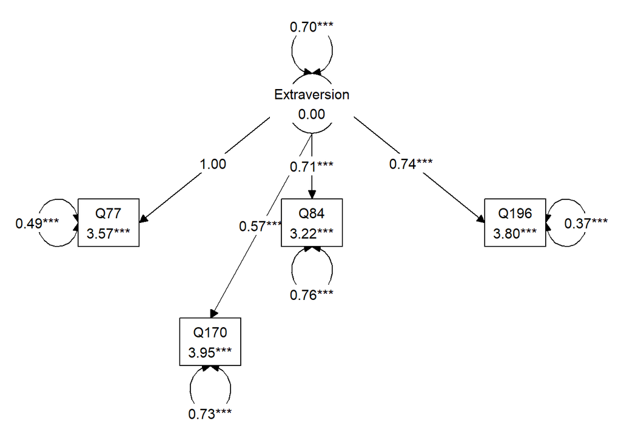

```r
# Alternative:
if (!require("tidySEM")) install.packages("tidySEM") # install this package first (once)
library(tidySEM)
graph_sem(fit_CFA)
```

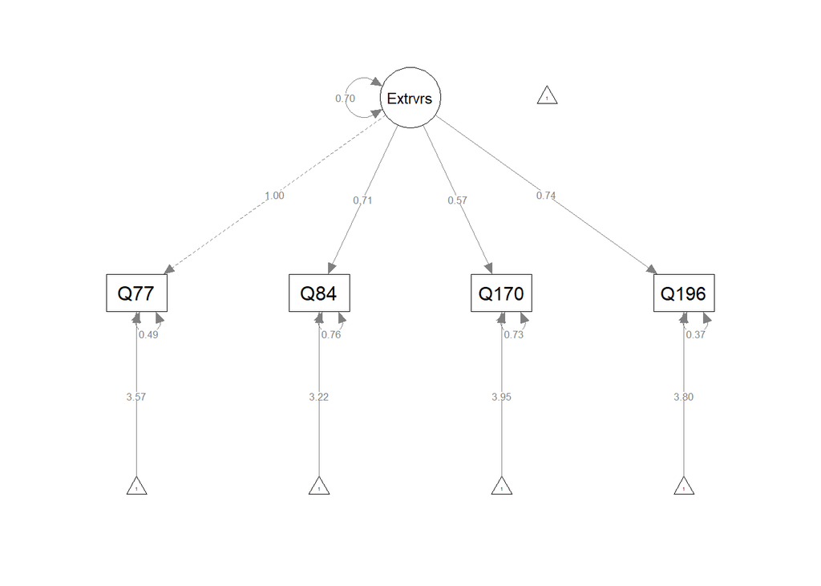

```r
# Another alternative:
if (!require("semPlot")) install.packages("semPlot") # install this package first (once)
library(semPlot)
semPaths(fit_CFA, "par", weighted = FALSE, nCharNodes = 7, shapeMan = "rectangle",
         sizeMan = 8, sizeMan2 = 5)
```

## 1.4 Exercise 1.4: Test equality of factor loadings

Based on the factor loadings, items do not seem to be equally reflective of Extraversion, except for Q84 and Q196. To improve the fit of the model, one can test whether these factor loadings are equal (resulting in estimating less parameters). One can use a Wald test to test whether two factor loadings can be considered equal.

### 1.4.1 Exercise 1.4a

Test whether the factor loadings of Q84 and Q196 are the same.

Hint: For a `lavaan` object (with label names!) one can do this with lavTestWald(fit, constrains = ‘<insert equality restriction>’).

**Click to show answers**

**Specify the model**

```r
# Specify model:
model.CFA_equal <- '
 # model with labeled parameters
 Extraversion =~ Q77 + a*Q84 + Q170 + b*Q196
'
```

**Fit the model**

```r
# Fit model:
fit_CFA_equal <- cfa(model.CFA_equal, data=data_sapi,
                     missing='fiml', fixed.x=F) # Specify FIML
```

**Conduct the Wald test**

```r
# Wald test
lavTestWald(fit_CFA_equal, constraints = 'a == b')
```

```
$stat
[1] 0.3619674

$df
[1] 1

$p.value
[1] 0.5474156

$se
[1] "standard"
```

### 1.4.2 Exercise 1.4b

What does the test imply?

**Click to show answers**

The Wald test with df=1 is 0.362, with $p$ = 0.547. Thus, we do not reject the null that the two loadings are equal. Hence, we conclude that there is no evidence for a difference between a and b, that is, the factor loadings of Q84 and Q196 are the same.

In case one wants the model results for which the loadings are the same:

```r
# Specify model:
model.CFA_equal <- '
 # model with labeled parameters
 Extraversion =~ Q77 + a*Q84 + Q170 + b*Q196
 #
 # constraints
 a == b
'
# Note: a* labels the parameter as ‘a’, used for model constraints.
#
# Alternatively:
model.CFA_equal <- '
 # model with labeled parameters
 Extraversion =~ Q77 + a*Q84 + Q170 + a*Q196
'

# Fit model:
fit_CFA_equal <- cfa(model.CFA_equal, data=data_sapi,
                     missing='fiml', fixed.x=F) # Specify FIML

# Model summary:
summary(fit_CFA_equal, standardized=TRUE, fit.measures=TRUE)
```

```
lavaan 0.6-19 ended normally after 24 iterations

  Estimator                                         ML
  Optimization method                           NLMINB
  Number of model parameters                        12
  Number of equality constraints                     1

  Number of observations                          1000
  Number of missing patterns                         5

Model Test User Model:

  Test statistic                                57.448
  Degrees of freedom                                 3
  P-value (Chi-square)                           0.000

Model Test Baseline Model:

  Test statistic                               844.837
  Degrees of freedom                                 6
  P-value                                        0.000

User Model versus Baseline Model:

  Comparative Fit Index (CFI)                    0.935
  Tucker-Lewis Index (TLI)                       0.870

  Robust Comparative Fit Index (CFI)             0.934
  Robust Tucker-Lewis Index (TLI)                0.868

Loglikelihood and Information Criteria:

  Loglikelihood user model (H0)              -5214.349
  Loglikelihood unrestricted model (H1)      -5185.625

  Akaike (AIC)                               10450.697
  Bayesian (BIC)                             10504.683
  Sample-size adjusted Bayesian (SABIC)      10469.746

Root Mean Square Error of Approximation:
```

[output cut: 30 more lines]

```

Intercepts:
                   Estimate  Std.Err  z-value  P(>|z|)   Std.lv  Std.all
   .Q77               3.571    0.034  103.668    0.000    3.571    3.283
   .Q84               3.224    0.034   95.958    0.000    3.224    3.043
   .Q170              3.947    0.031  127.448    0.000    3.947    4.040
   .Q196              3.800    0.028  138.079    0.000    3.800    4.384

Variances:
                   Estimate  Std.Err  z-value  P(>|z|)   Std.lv  Std.all
   .Q77               0.476    0.044   10.737    0.000    0.476    0.403
   .Q84               0.754    0.039   19.523    0.000    0.754    0.672
   .Q170              0.734    0.037   19.637    0.000    0.734    0.769
   .Q196              0.383    0.026   14.967    0.000    0.383    0.509
    Extraversion      0.706    0.062   11.346    0.000    1.000    1.000
```

```r
fitMeasures(fit_CFA_equal, c("cfi", "tli", "rmsea","srmr"))
```

```
  cfi   tli rmsea  srmr
0.935 0.870 0.135 0.042
```

The measures did improve, but the model still does not fit well.

## 1.5 Exercise 1.5: EFA vs CFA

Specify and run the two-factor exploratory factor model (EFA) and two-factor CFA, as was shown in the lecture slides (using the items: Q44, Q63, Q76, Q77, Q84, Q98, Q170, and Q196).

**Click to show answers**

**Data screening: Item correlations**

```r
# Correlations for the items of interest: Q44 Q63 Q76 Q77 Q84 Q98 Q170 Q196
res <- rcorr(as.matrix(data_sapi[, c(6:13)])) # rcorr() accepts matrices only
# Correlation matrix (rounded to 3 decimals)
round(res$r, 3)
```

```
       Q44   Q63   Q76   Q77   Q84   Q98  Q170  Q196
Q44  1.000 0.309 0.296 0.136 0.179 0.264 0.173 0.181
Q63  0.309 1.000 0.290 0.275 0.224 0.358 0.198 0.292
Q76  0.296 0.290 1.000 0.259 0.268 0.298 0.197 0.241
Q77  0.136 0.275 0.259 1.000 0.487 0.285 0.323 0.534
Q84  0.179 0.224 0.268 0.487 1.000 0.353 0.204 0.353
Q98  0.264 0.358 0.298 0.285 0.353 1.000 0.270 0.328
Q170 0.173 0.198 0.197 0.323 0.204 0.270 1.000 0.449
Q196 0.181 0.292 0.241 0.534 0.353 0.328 0.449 1.000
```

**Specify the two-factor EFA model**

The efa(‘block1’) modifier indicates that the factors comprise an exploratory block (with the name block1) and thus that we do not exactly know the loading structure of the variables / items on these factors.

```r
# Specify two-factor EFA model:
model.2EFA <- "
 efa('block1')*Having fun  =~ Q77 + Q84 + Q170 + Q196 + Q44 + Q63 + Q76 + Q98
 efa('block1')*Being liked =~ Q77 + Q84 + Q170 + Q196 + Q44 + Q63 + Q76 + Q98
"
# Alternative:
model.2EFA <- "
efa('block1')*Having fun  + efa('block1')*Being liked =~
Q77 + Q84 + Q170 + Q196 + Q44 + Q63 + Q76 + Q98
"
```

**Fit the two-factor EFA model**

```r
# Fit two-factor EFA model:
fit_2EFA <- cfa(model.2EFA, data=data_sapi,
                missing='fiml', fixed.x=F) # Specify FIML
# This estimates the EFA model (releasing the residual variances and implying the EFA constraints) using the oblique geomin rotation.

# Model summary:
summary(fit_2EFA)
```

```
lavaan 0.6-19 ended normally after 32 iterations

  Estimator                                         ML
  Optimization method                           NLMINB
  Number of model parameters                        33
  Row rank of the constraints matrix                 2

  Rotation method                       GEOMIN OBLIQUE
  Geomin epsilon                                 0.001
  Rotation algorithm (rstarts)                GPA (30)
  Standardized metric                             TRUE
  Row weights                                     None

  Number of observations                          1000
  Number of missing patterns                        10

Model Test User Model:

  Test statistic                                89.155
  Degrees of freedom                                13
  P-value (Chi-square)                           0.000

Parameter Estimates:

  Standard errors                             Standard
  Information                                 Observed
  Observed information based on                Hessian

Latent Variables:
                            Estimate  Std.Err  z-value  P(>|z|)
  Having      fun =~ block1
    Q77                        0.884    0.042   21.269    0.000
    Q84                        0.493    0.056    8.848    0.000
    Q170                       0.336    0.073    4.608    0.000
    Q196                       0.523    0.070    7.485    0.000
    Q44                       -0.163    0.055   -2.975    0.003
    Q63                        0.014    0.025    0.553    0.580
    Q76                        0.031    0.056    0.563    0.573
    Q98                        0.085    0.058    1.472    0.141
  Being     liked =~ block1
```

[output cut: 22 more lines]

```
   .Q76               3.320    0.037   89.180    0.000
   .Q98               3.896    0.028  141.409    0.000

Variances:
                   Estimate  Std.Err  z-value  P(>|z|)
   .Q77               0.429    0.071    6.077    0.000
   .Q84               0.727    0.038   19.260    0.000
   .Q170              0.734    0.037   20.016    0.000
   .Q196              0.398    0.030   13.201    0.000
   .Q44               0.598    0.041   14.572    0.000
   .Q63               0.816    0.050   16.405    0.000
   .Q76               1.005    0.056   18.074    0.000
   .Q98               0.489    0.029   16.612    0.000
    Havingfun         1.000
    Beingliked        1.000
```

```r
lavInspect(fit_2EFA)
```

```
$lambda
     Hvngfn Bnglkd
Q77       1      9
Q84       2     10
Q170      3     11
Q196      4     12
Q44       5     13
Q63       6     14
Q76       7     15
Q98       8     16

$theta
     Q77 Q84 Q170 Q196 Q44 Q63 Q76 Q98
Q77   17
Q84    0  18
Q170   0   0   19
Q196   0   0    0   20
Q44    0   0    0    0  21
Q63    0   0    0    0   0  22
Q76    0   0    0    0   0   0  23
Q98    0   0    0    0   0   0   0  24

$psi
                Hvngfn Bnglkd
Having      fun      0
Being     liked     25      0

$nu
     intrcp
Q77      26
Q84      27
Q170     28
Q196     29
Q44      30
Q63      31
Q76      32
Q98      33

$alpha
                intrcp
Having      fun      0
Being     liked      0
```

**Specify and fit the two-factor CFA model**

```r
# Specify two-factor CFA model:
model.2CFA <- "
 Having fun  =~ Q77 + Q84 + Q170 + Q196
 Being liked =~ Q44 + Q63 + Q76 + Q98
"
# Fit two-factor CFA model:
fit_2CFA <- cfa(model.2CFA, data=data_sapi,
                missing='fiml', fixed.x=F) # Specify FIML

# Model summary:
summary(fit_2CFA)
```

```
lavaan 0.6-19 ended normally after 44 iterations

  Estimator                                         ML
  Optimization method                           NLMINB
  Number of model parameters                        25

  Number of observations                          1000
  Number of missing patterns                        10

Model Test User Model:

  Test statistic                               124.170
  Degrees of freedom                                19
  P-value (Chi-square)                           0.000

Parameter Estimates:

  Standard errors                             Standard
  Information                                 Observed
  Observed information based on                Hessian

Latent Variables:
                     Estimate  Std.Err  z-value  P(>|z|)
  Having      fun =~
    Q77                 1.000
    Q84                 0.763    0.049   15.710    0.000
    Q170                0.617    0.049   12.649    0.000
    Q196                0.784    0.046   17.150    0.000
  Being     liked =~
    Q44                 1.000
    Q63                 1.534    0.144   10.637    0.000
    Q76                 1.444    0.143   10.134    0.000
    Q98                 1.268    0.122   10.354    0.000

Covariances:
                     Estimate  Std.Err  z-value  P(>|z|)
  Having      fun ~~
    Beingliked          0.231    0.024    9.669    0.000

Intercepts:
                   Estimate  Std.Err  z-value  P(>|z|)
   .Q77               3.570    0.034  103.637    0.000
   .Q84               3.224    0.033   96.481    0.000
   .Q170              3.947    0.031  127.448    0.000
   .Q196              3.801    0.028  137.640    0.000
   .Q44               3.341    0.029  114.538    0.000
   .Q63               3.590    0.035  102.447    0.000
   .Q76               3.320    0.037   89.181    0.000
   .Q98               3.896    0.028  141.407    0.000

Variances:
                   Estimate  Std.Err  z-value  P(>|z|)
   .Q77               0.546    0.039   14.035    0.000
   .Q84               0.740    0.040   18.528    0.000
   .Q170              0.712    0.036   19.747    0.000
   .Q196              0.365    0.025   14.558    0.000
   .Q44               0.668    0.034   19.554    0.000
   .Q63               0.801    0.047   16.982    0.000
   .Q76               1.005    0.054   18.544    0.000
   .Q98               0.467    0.029   16.106    0.000
    Havingfun         0.638    0.056   11.380    0.000
    Beingliked        0.180    0.029    6.300    0.000
```

```r
lavInspect(fit_2CFA)
```

```
$lambda
     Hvngfn Bnglkd
Q77       0      0
Q84       1      0
Q170      2      0
Q196      3      0
Q44       0      0
Q63       0      4
Q76       0      5
Q98       0      6

$theta
     Q77 Q84 Q170 Q196 Q44 Q63 Q76 Q98
Q77    7
Q84    0   8
Q170   0   0    9
Q196   0   0    0   10
Q44    0   0    0    0  11
Q63    0   0    0    0   0  12
Q76    0   0    0    0   0   0  13
Q98    0   0    0    0   0   0   0  14

$psi
                Hvngfn Bnglkd
Having      fun     15
Being     liked     17     16

$nu
     intrcp
Q77      18
Q84      19
Q170     20
Q196     21
Q44      22
Q63      23
Q76      24
Q98      25

$alpha
                intrcp
Having      fun      0
Being     liked      0
```

# 2 Exercise 2: EFA

Use the data file popular_factor.txt. Make sure to denote that 99 represents a missing value.

## 2.1 Exercise 2a

Run an EFA that provides you with a 1-factor and a 2-factor solution. Interpret the results for the 2-factor solution.

**Click to show answers**

**Load the data**

```r
# Read in data:
data_pop <- read.table("popular_factor.txt", header = T)
# Denote missing values:
data_pop[sapply(data_pop, function(x) as.character(x) %in% c("99") )] <- NA
```

**Data screening: Item correlations**

```r
# Correlations for the items of interest
res <- rcorr(as.matrix(data_pop)) # rcorr() accepts matrices only
round(res$r, 3) # Correlation matrix (rounded to 3 decimals)
```

```
      c1     c2    c3    o1     o2    o3
c1 1.000  0.388 0.318 0.154  0.002 0.099
c2 0.388  1.000 0.411 0.204 -0.005 0.066
c3 0.318  0.411 1.000 0.261  0.056 0.090
o1 0.154  0.204 0.261 1.000  0.163 0.194
o2 0.002 -0.005 0.056 0.163  1.000 0.095
o3 0.099  0.066 0.090 0.194  0.095 1.000
```

**One-factor model**

```r
# Specify one-factor EFA model:
model.1EFA <- "
 efa('block1')*F1  =~ c1 + c2 + c3 + o1 + o2 + o3
"

# Fit one-factor EFA model:
fit_1EFA <- cfa(model.1EFA, data=data_pop,
                missing='fiml', fixed.x=F) # Specify FIML

# Model summary:
summary(fit_1EFA)
```

```
lavaan 0.6-19 ended normally after 20 iterations

  Estimator                                         ML
  Optimization method                           NLMINB
  Number of model parameters                        18

  Rotation method                       GEOMIN OBLIQUE
  Geomin epsilon                                 0.001
  Rotation algorithm (rstarts)                GPA (30)
  Standardized metric                             TRUE
  Row weights                                     None

                                                  Used       Total
  Number of observations                          1344        1491
  Number of missing patterns                         9

Model Test User Model:

  Test statistic                                88.907
  Degrees of freedom                                 9
  P-value (Chi-square)                           0.000

Parameter Estimates:

  Standard errors                             Standard
  Information                                 Observed
  Observed information based on                Hessian

Latent Variables:
                   Estimate  Std.Err  z-value  P(>|z|)
  F1 =~ block1
    c1                0.464    0.028   16.641    0.000
    c2                0.615    0.032   19.503    0.000
    c3                0.598    0.032   18.614    0.000
    o1                0.233    0.022   10.729    0.000
    o2                0.013    0.006    2.023    0.043
    o3                0.102    0.021    4.940    0.000

Intercepts:
                   Estimate  Std.Err  z-value  P(>|z|)
   .c1                1.765    0.023   75.159    0.000
   .c2                2.560    0.026  100.248    0.000
   .c3                2.147    0.026   81.737    0.000
   .o1                1.299    0.018   73.558    0.000
   .o2                1.024    0.005  203.841    0.000
   .o3                1.243    0.017   74.408    0.000

Variances:
                   Estimate  Std.Err  z-value  P(>|z|)
   .c1                0.522    0.026   20.115    0.000
   .c2                0.493    0.033   14.899    0.000
   .c3                0.565    0.034   16.591    0.000
   .o1                0.364    0.015   23.657    0.000
   .o2                0.034    0.001   25.808    0.000
   .o3                0.363    0.014   25.471    0.000
    F1                1.000
```

```r
fitMeasures(fit_1EFA, c("chisq", "df", "pvalue", "cfi", "tli", "rmsea","srmr"))
```

```
 chisq     df pvalue    cfi    tli  rmsea   srmr
88.907  9.000  0.000  0.888  0.813  0.081  0.046
```

```r
lavInspect(fit_1EFA)
```

```
$lambda
   F1
c1  1
c2  2
c3  3
o1  4
o2  5
o3  6

$theta
   c1 c2 c3 o1 o2 o3
c1  7
c2  0  8
c3  0  0  9
o1  0  0  0 10
o2  0  0  0  0 11
o3  0  0  0  0  0 12

$psi
   F1
F1  0

$nu
   intrcp
c1     13
c2     14
c3     15
o1     16
o2     17
o3     18

$alpha
   intrcp
F1      0
```

**Two-factor model**

```r
# Specify two-factor EFA model:
model.2EFA <- "
 efa('block1')*F1  =~ c1 + c2 + c3 + o1 + o2 + o3
 efa('block1')*F2  =~ c1 + c2 + c3 + o1 + o2 + o3
"
# Fit two-factor EFA model:
fit_2EFA <- cfa(model.2EFA, data=data_pop,
                missing='fiml', fixed.x=F) # Specify FIML

# Model summary:
summary(fit_2EFA)
```

```
lavaan 0.6-19 ended normally after 30 iterations

  Estimator                                         ML
  Optimization method                           NLMINB
  Number of model parameters                        25
  Row rank of the constraints matrix                 2

  Rotation method                       GEOMIN OBLIQUE
  Geomin epsilon                                 0.001
  Rotation algorithm (rstarts)                GPA (30)
  Standardized metric                             TRUE
  Row weights                                     None

                                                  Used       Total
  Number of observations                          1344        1491
  Number of missing patterns                         9

Model Test User Model:

  Test statistic                                 4.721
  Degrees of freedom                                 4
  P-value (Chi-square)                           0.317

Parameter Estimates:

  Standard errors                             Standard
  Information                                 Observed
  Observed information based on                Hessian

Latent Variables:
                   Estimate  Std.Err  z-value  P(>|z|)
  F1 =~ block1
    c1                0.460    0.038   12.202    0.000
    c2                0.675    0.041   16.569    0.000
    c3                0.483    0.042   11.388    0.000
    o1                0.017    0.018    0.931    0.352
    o2               -0.026    0.009   -2.833    0.005
    o3               -0.020    0.027   -0.736    0.462
  F2 =~ block1
    c1                0.013    0.034    0.373    0.709
```

[output cut: 15 more lines]

```
   .c3                2.147    0.026   81.739    0.000
   .o1                1.300    0.018   73.586    0.000
   .o2                1.024    0.005  203.858    0.000
   .o3                1.243    0.017   74.418    0.000

Variances:
                   Estimate  Std.Err  z-value  P(>|z|)
   .c1                0.521    0.028   18.820    0.000
   .c2                0.425    0.044    9.715    0.000
   .c3                0.589    0.033   18.082    0.000
   .o1                0.255    0.037    6.983    0.000
   .o2                0.031    0.002   19.917    0.000
   .o3                0.338    0.016   21.066    0.000
    F1                1.000
    F2                1.000
```

```r
fitMeasures(fit_2EFA, c("chisq", "df", "pvalue", "cfi", "tli", "rmsea","srmr"))
```

```
 chisq     df pvalue    cfi    tli  rmsea   srmr
 4.721  4.000  0.317  0.999  0.996  0.012  0.009
```

```r
lavInspect(fit_2EFA)
```

```
$lambda
   F1 F2
c1  1  7
c2  2  8
c3  3  9
o1  4 10
o2  5 11
o3  6 12

$theta
   c1 c2 c3 o1 o2 o3
c1 13
c2  0 14
c3  0  0 15
o1  0  0  0 16
o2  0  0  0  0 17
o3  0  0  0  0  0 18

$psi
   F1 F2
F1  0
F2 19  0

$nu
   intrcp
c1     20
c2     21
c3     22
o1     23
o2     24
o3     25

$alpha
   intrcp
F1      0
F2      0
```

One can conclude that the 2-factor structure fits well to the data:

- Chi-Square Test of Model Fit is not significant,
- CFI/TLI is > 0.95, and
- RMSEA is < 0.05.

## 2.2 Exercise 2b

Which factor model do you prefer?

Note: you can use for example the `anova()` function for this.

**Click to show answers**

**Compare the two models**

```r
# Compare the one-factor model to the two-factor model

# Option 1:
anova(fit_1EFA, fit_2EFA)
```

```
Chi-Squared Difference Test

         Df   AIC   BIC   Chisq Chisq diff   RMSEA Df diff Pr(>Chisq)
fit_2EFA  4 14367 14486  4.7208
fit_1EFA  9 14441 14535 88.9075     84.187 0.10855       5  < 2.2e-16 ***
---
Signif. codes:  0 '***' 0.001 '**' 0.01 '*' 0.05 '.' 0.1 ' ' 1
```

```r
# In case you want to quantify the relative support (so, how much better).
# Based on the AIC:
fit_EFA_AIC <- anova(fit_1EFA, fit_2EFA)$AIC
#names(fit_EFA_AIC) <- c("2EFA", "1EFA") # Note 2EFA comes first! # names not needed
#fit_EFA_AIC
#if (!require("restriktor")) install.packages("restriktor", dependencies = TRUE)
library(restriktor) # ?calc_ICweights
AIC_weights_EFA <- calc_ICweights(fit_EFA_AIC, hypo_names = c("2EFA", "1EFA"))
AIC_weights_EFA$IC_weights
```

```
          2EFA           1EFA
"1.000000e+00" "7.772504e-17"
```

```r
AIC_weights_EFA$ratio_IC_weights[1,2]
```

```
[1] "1.286587e+16"
```

```r
# Note: More information in IC weights can be found in the Model Selection lecture.
```

The Chi-square difference test is significant, implying that the null (stating that two factors are one and the same) is rejected. Additionally, the AIC and BIC for the 2-factor model is lower than for the 1-factor model. Moreover, the 2-factor model is infinite more supported than the 1-factor model.  
Hence, we prefer the 2-factor model.

There are alternative ways to compare the models, such as:

```r
# Option 2:
if (!require("performance")) install.packages("performance", dependencies = TRUE)
library(performance)

compare_performance(fit_1EFA, fit_2EFA)


# In case you want to quantify the relative support (so, how much better).
# Based on the AIC:
fit_EFA_AIC <- compare_performance(fit_1EFA, fit_2EFA)$AIC
names(fit_EFA_AIC) <- c("1EFA", "2EFA") # names not needed
#fit_EFA_AIC
library(restriktor) # ?calc_ICweights
AIC_weights_EFA <- calc_ICweights(fit_EFA_AIC, hypo_names = c("1EFA", "2EFA"))
AIC_weights_EFA$IC_weights
AIC_weights_EFA$ratio_IC_weights[1,2]
# Note: More information in IC weights can be found in the Model Selection lecture.
```

**Plot the results**

Using `lavaanPlot()`:

```r
# Plot
if (!require("lavaanPlot")) install.packages("lavaanPlot") # install this package first (once)
library(lavaanPlot)
lavaanPlot(model = fit_2EFA, node_options = list(shape = "box", fontname = "Helvetica"),
           edge_options = list(color = "grey"), coefs = T, stand = T, covs = T)
```

[interactive chart not shown]

Using `tidySEM()` and `semPlot()`:

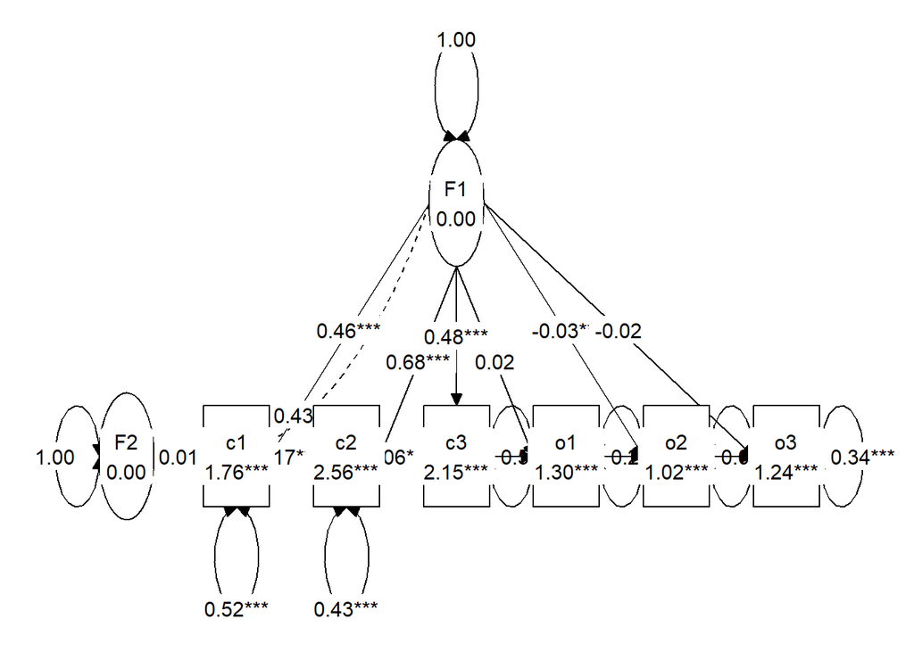

```r
# Alternative
if (!require("tidySEM")) install.packages("tidySEM") # install this package first (once)
library(tidySEM)
graph_sem(fit_2EFA)
```

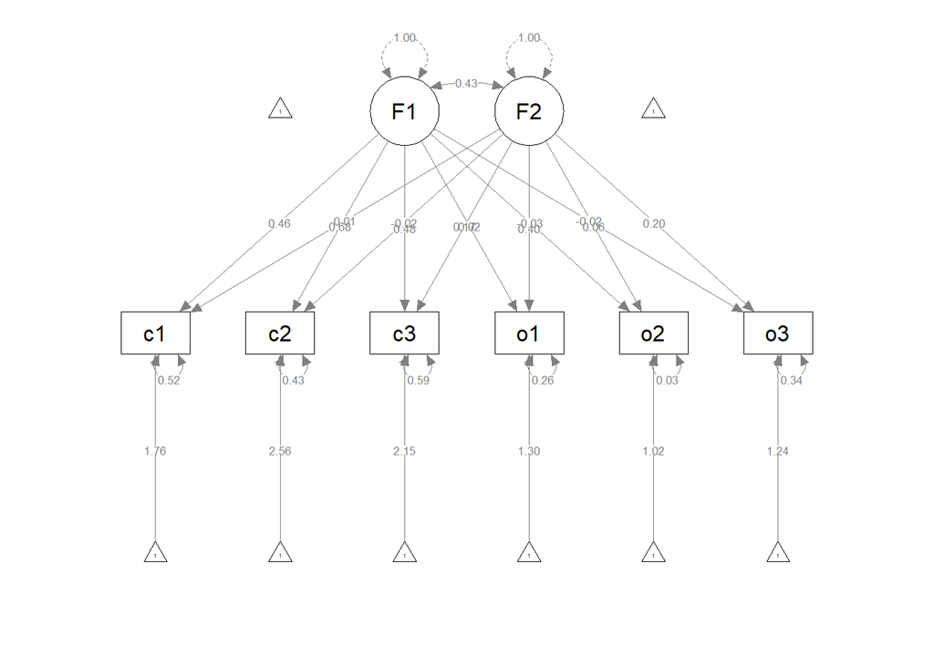

```r
# Another alternative
if (!require("semPlot")) install.packages("semPlot") # install this package first (once)
library(semPlot)
semPaths(fit_2EFA, "par", weighted = FALSE, nCharNodes = 7, shapeMan = "rectangle",
         sizeMan = 8, sizeMan2 = 5)
```

# 3 Exercise 3: CFA

Use again data file popular_factor.txt.

## 3.1 Exercise 3a

Now, run a CFA with 1 factor (‘anti’) and another model with 2-factors (‘covert’ and ‘overt’) based on the 2-factor EFA model. Bear in mind that you should normally not run both an EFA and CFA on the same data set; normally, the EFA model generates a hypothesis for a next study (or for another part of your data set).

In both models, scale by fixing the factor variance, rather than by fixing a loading (in the last question, it will become clear why).

**Click to show answers**

**Load the data**

```r
# Read in data:
data_pop <- read.table("popular_factor.txt", header = T)
# Denote missing values:
data_pop[sapply(data_pop, function(x) as.character(x) %in% c("99") )] <- NA
```

**One-factor CFA model**

```r
# Specify one-factor CFA model:
model.1CFA <- "
 anti  =~ NA*c1 + c2 + c3 + o1 + o2 + o3
 anti ~~ 1*anti
"

# Fit one-factor CFA model:
fit_1CFA <- cfa(model.1CFA, data=data_pop,
                missing='fiml', fixed.x=F) # Specify FIML

# Model summary:
summary(fit_1CFA)
```

```
lavaan 0.6-19 ended normally after 28 iterations

  Estimator                                         ML
  Optimization method                           NLMINB
  Number of model parameters                        18

                                                  Used       Total
  Number of observations                          1344        1491
  Number of missing patterns                         9

Model Test User Model:

  Test statistic                                88.907
  Degrees of freedom                                 9
  P-value (Chi-square)                           0.000

Parameter Estimates:

  Standard errors                             Standard
  Information                                 Observed
  Observed information based on                Hessian

Latent Variables:
                   Estimate  Std.Err  z-value  P(>|z|)
  anti =~
    c1                0.464    0.028   16.641    0.000
    c2                0.615    0.032   19.503    0.000
    c3                0.598    0.032   18.614    0.000
    o1                0.233    0.022   10.729    0.000
    o2                0.013    0.006    2.023    0.043
    o3                0.102    0.021    4.940    0.000

Intercepts:
                   Estimate  Std.Err  z-value  P(>|z|)
   .c1                1.765    0.023   75.159    0.000
   .c2                2.560    0.026  100.248    0.000
   .c3                2.147    0.026   81.737    0.000
   .o1                1.299    0.018   73.558    0.000
   .o2                1.024    0.005  203.841    0.000
   .o3                1.243    0.017   74.408    0.000

Variances:
                   Estimate  Std.Err  z-value  P(>|z|)
    anti              1.000
   .c1                0.522    0.026   20.115    0.000
   .c2                0.493    0.033   14.899    0.000
   .c3                0.565    0.034   16.591    0.000
   .o1                0.364    0.015   23.657    0.000
   .o2                0.034    0.001   25.808    0.000
   .o3                0.363    0.014   25.471    0.000
```

```r
fitMeasures(fit_1CFA, c("chisq", "df", "pvalue", "cfi", "tli", "rmsea","srmr"))
```

```
 chisq     df pvalue    cfi    tli  rmsea   srmr
88.907  9.000  0.000  0.888  0.813  0.081  0.046
```

```r
lavInspect(fit_1CFA)
```

```
$lambda
   anti
c1    1
c2    2
c3    3
o1    4
o2    5
o3    6

$theta
   c1 c2 c3 o1 o2 o3
c1  7
c2  0  8
c3  0  0  9
o1  0  0  0 10
o2  0  0  0  0 11
o3  0  0  0  0  0 12

$psi
     anti
anti    0

$nu
   intrcp
c1     13
c2     14
c3     15
o1     16
o2     17
o3     18

$alpha
     intrcp
anti      0
```

**Two-factor CFA model**

```r
# Specify two-factor CFA model:
model.2CFA <- "
 covert  =~ NA*c1 + c2 + c3
 overt   =~ NA*o1 + o2 + o3
 covert ~~ 1*covert
 overt ~~ 1*overt
"
# Fit two-factor CFA model:
fit_2CFA <- cfa(model.2CFA, data=data_pop,
                missing='fiml', fixed.x=F) # Specify FIML

# Model summary:
summary(fit_2CFA)
```

```
lavaan 0.6-19 ended normally after 32 iterations

  Estimator                                         ML
  Optimization method                           NLMINB
  Number of model parameters                        19

                                                  Used       Total
  Number of observations                          1344        1491
  Number of missing patterns                         9

Model Test User Model:

  Test statistic                                25.730
  Degrees of freedom                                 8
  P-value (Chi-square)                           0.001

Parameter Estimates:

  Standard errors                             Standard
  Information                                 Observed
  Observed information based on                Hessian

Latent Variables:
                   Estimate  Std.Err  z-value  P(>|z|)
  covert =~
    c1                0.466    0.028   16.724    0.000
    c2                0.630    0.032   19.634    0.000
    c3                0.593    0.033   18.208    0.000
  overt =~
    o1                0.500    0.057    8.797    0.000
    o2                0.038    0.007    5.512    0.000
    o3                0.160    0.027    5.960    0.000

Covariances:
                   Estimate  Std.Err  z-value  P(>|z|)
  covert ~~
    overt             0.431    0.055    7.806    0.000

Intercepts:
                   Estimate  Std.Err  z-value  P(>|z|)
   .c1                1.765    0.023   75.160    0.000
   .c2                2.560    0.026  100.241    0.000
   .c3                2.147    0.026   81.736    0.000
   .o1                1.300    0.018   73.580    0.000
   .o2                1.024    0.005  203.848    0.000
   .o3                1.243    0.017   74.419    0.000

Variances:
                   Estimate  Std.Err  z-value  P(>|z|)
    covert            1.000
    overt             1.000
   .c1                0.521    0.026   20.096    0.000
   .c2                0.475    0.034   13.886    0.000
   .c3                0.570    0.035   16.457    0.000
   .o1                0.168    0.055    3.033    0.002
   .o2                0.032    0.001   24.885    0.000
   .o3                0.348    0.015   23.135    0.000
```

```r
fitMeasures(fit_2CFA, c("chisq", "df", "pvalue", "cfi", "tli", "rmsea","srmr"))
```

```
 chisq     df pvalue    cfi    tli  rmsea   srmr
25.730  8.000  0.001  0.975  0.953  0.041  0.024
```

```r
lavInspect(fit_2CFA)
```

```
$lambda
   covert overt
c1      1     0
c2      2     0
c3      3     0
o1      0     4
o2      0     5
o3      0     6

$theta
   c1 c2 c3 o1 o2 o3
c1  7
c2  0  8
c3  0  0  9
o1  0  0  0 10
o2  0  0  0  0 11
o3  0  0  0  0  0 12

$psi
       covert overt
covert      0
overt      13     0

$nu
   intrcp
c1     14
c2     15
c3     16
o1     17
o2     18
o3     19

$alpha
       intrcp
covert      0
overt       0
```

## 3.2 Exercise 3b

Which model is to be preferred? What can you say about the model fit based on the AIC and BIC?

**Click to show answers**

```r
# Compare the one-factor model to the two-factor model
anova(fit_1CFA, fit_2CFA)
```

```
Chi-Squared Difference Test

         Df   AIC   BIC  Chisq Chisq diff   RMSEA Df diff Pr(>Chisq)
fit_2CFA  8 14380 14479 25.730
fit_1CFA  9 14441 14535 88.907     63.178 0.21509       1  1.889e-15 ***
---
Signif. codes:  0 '***' 0.001 '**' 0.01 '*' 0.05 '.' 0.1 ' ' 1
```

```r
# In case you want to quantify the relative support (so, how much better).
# Based on the AIC:
fit_AIC <- anova(fit_1CFA, fit_2CFA)$AIC
names(fit_AIC) <- c("2CFA", "1CFA") # Note 2CFA comes first! # names not needed
#fit_AIC
#library(restriktor)
AIC_weights <- calc_ICweights(fit_AIC, hypo_names = c("2CFA", "1CFA"))
AIC_weights$IC_weights
```

```
          2CFA           1CFA
"1.000000e+00" "5.192797e-14"
```

```r
AIC_weights$ratio_IC_weights[1,2]
```

```
[1] "1.925744e+13"
```

```r
# Note: More information in IC weights can be found in the Model Selection lecture.
```

The Chi-square difference test is significant, implying that the null (stating that the two factors are one and the same) is rejected. Additionally, the AIC and BIC for the 2-factor model is lower than for the 1-factor model. Moreover, the 2-factor model is infinite more supported than the 1-factor model.  
Hence, we prefer the 2-factor model.

```r
fitMeasures(fit_1CFA, c("chisq", "df", "pvalue", "cfi", "tli", "rmsea","srmr"))
```

```
 chisq     df pvalue    cfi    tli  rmsea   srmr
88.907  9.000  0.000  0.888  0.813  0.081  0.046
```

```r
fitMeasures(fit_2CFA, c("chisq", "df", "pvalue", "cfi", "tli", "rmsea","srmr"))
```

```
 chisq     df pvalue    cfi    tli  rmsea   srmr
25.730  8.000  0.001  0.975  0.953  0.041  0.024
```

## 3.3 Exercise 3c

What is the correlation between the two factors (i.e., overt and covert)?

**Click to show a hint**

Whether the unstandardized ‘covert ~~ overt’ can be interpreted as a correlation or a covariance, depends on how the latent variable was scaled:

- If the factor variances are fixed to 1 (i.e., when scaling is done via the factor variances), then the ‘unstandardized’ result reflects the factor correlation.
- Otherwise they reflect the covariance.

**Click to show answers**

The correlation between the two factors is:

```r
parameterEstimates(fit_2CFA)[15,]
```

```
      lhs op   rhs   est    se     z pvalue ci.lower ci.upper
15 covert ~~ overt 0.431 0.055 7.806      0    0.323    0.539
```

The correlation between overt and covert is 0.431 with a standard error of 0.055.

Consequently, the proportion of shared variance is 0.4312^2 = 0.186 = 18.6%.

**Plot the results**

Using `lavaanPlot()`:

```r
# Plot
if (!require("lavaanPlot")) install.packages("lavaanPlot") # install this package first (once)
library(lavaanPlot)
lavaanPlot(model = fit_2CFA, node_options = list(shape = "box", fontname = "Helvetica"),
           edge_options = list(color = "grey"), coefs = T, stand = T, covs = T)
```

[interactive chart not shown]

Using `tidySEM()` or `semPlot()`:

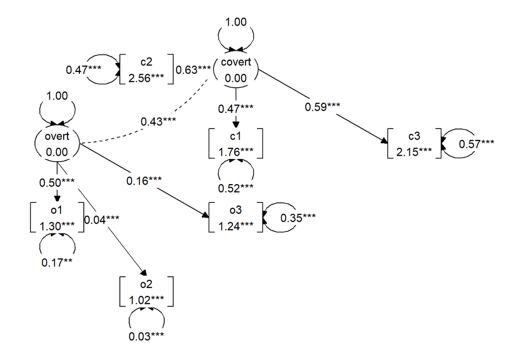

```r
# Alternative
if (!require("tidySEM")) install.packages("tidySEM") # install this package first (once)
library(tidySEM)
graph_sem(fit_2CFA)
```

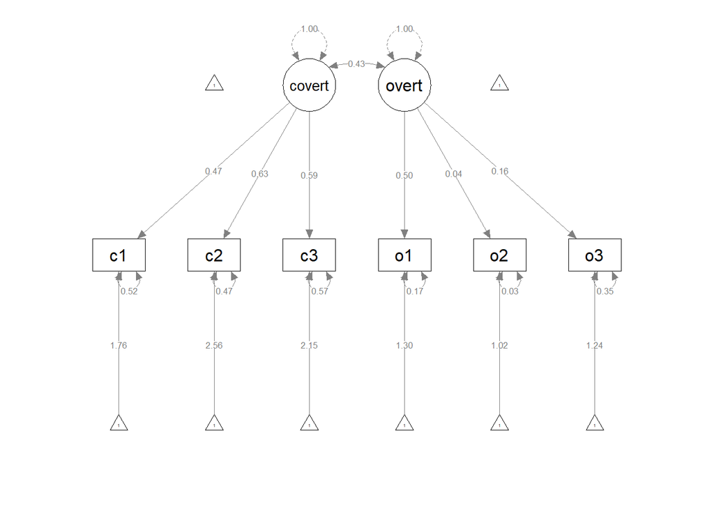

```r
# Another alternative
if (!require("semPlot")) install.packages("semPlot") # install this package first (once)
library(semPlot)
semPaths(fit_2CFA, "par", weighted = FALSE, nCharNodes = 7, shapeMan = "rectangle",
         sizeMan = 8, sizeMan2 = 5)
```